# *Economic Performance, Child Mortality, and AIDS Orphanhood: A Global Health Perspective*

## 5. DONUT CHART

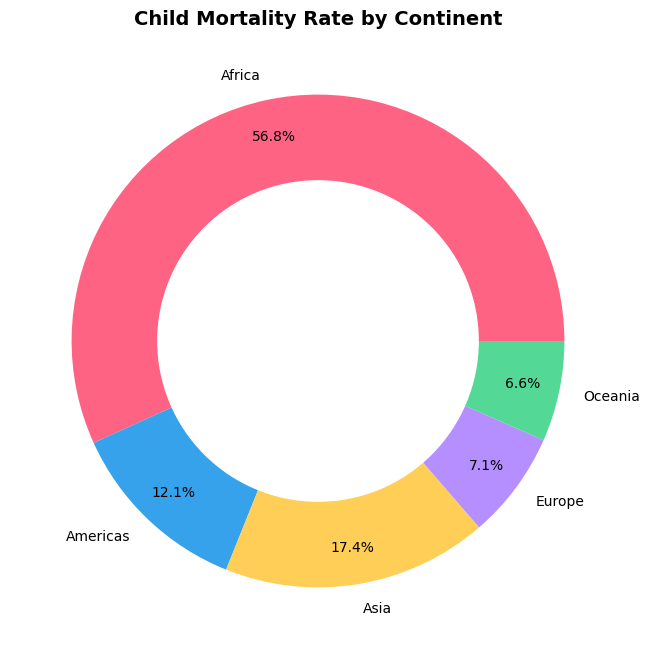

```python
import pandas as pd
import geopandas as gpd
import matplotlib.pyplot as plt


Mortality = pd.read_csv("/content/unicef_indicator_1.csv", usecols=["country", "time_period", "obs_value"])
WorldData = gpd.read_file("/content/world-administrative-boundaries.shp")[["name", "continent"]]


Mortality.rename(columns={"country": "Country", "time_period": "Year", "obs_value": "Child Mortality Rate"}, inplace=True)


Mortality["Child Mortality Rate"] = pd.to_numeric(Mortality["Child Mortality Rate"], errors="coerce")


Mortality_with_continent = Mortality.merge(WorldData, left_on="Country", right_on="name", how="left").dropna()


continent_mortality = Mortality_with_continent.groupby("continent")["Child Mortality Rate"].sum().reset_index()


colors = ["#FF6384", "#36A2EB", "#FFCE56", "#B58EFF", "#54D896"]


plt.figure(figsize=(8, 8))
plt.pie(continent_mortality["Child Mortality Rate"], labels=continent_mortality["continent"], colors=colors, autopct="%1.1f%%", pctdistance=0.85)
plt.gca().add_artist(plt.Circle((0, 0), 0.65, color='white'))


plt.title("Child Mortality Rate by Continent", fontsize=14, fontweight="bold")
plt.show()
```

The donut chart presents the proportional distribution of child mortality rates across different continents, providing a visual representation of global disparities in health outcomes for children. The data illustrates significant regional differences, emphasizing the socioeconomic, healthcare, and policy-driven factors that contribute to these variations.

Africa exhibits the highest child mortality rate at 56.8%, highlighting systemic challenges such as limited healthcare access, high rates of infectious diseases, malnutrition, and inadequate maternal and neonatal care infrastructure. Many countries in this region experience constrained medical resources and economic instability, which directly impact child survival rates.

Asia, accounting for 17.4% of global child mortality, demonstrates a mixed trend; while some nations have achieved substantial progress due to economic growth and healthcare advancements, others still struggle with rural healthcare accessibility, poverty, and disease burden.

The Americas (12.1%), Europe (7.1%), and Oceania (6.6%) report significantly lower mortality rates, suggesting stronger healthcare systems, comprehensive vaccination programs, higher living standards, and well-established public health policies that contribute to lower child mortality

# CONCLUSION

Moving forward, targeted investments in healthcare, education, and social infrastructure are essential to narrowing these gaps. The findings emphasize the urgent need for policy reforms, increased humanitarian aid, and sustainable development strategies to ensure equitable child survival rates worldwide.

[figure not shown]

UNI212395.jpg